# GWAS-по-EBV

Для начала то, что необходимо всегда помнить. Принципы case-control GWAS:

- case и control взяты из одной популяции;
- case отобраны, ошибочные case будут значительно снижать статистическую мощность исследования;
- генетические и эпидемиологические данные cases и controls собраны одинаково;
- отобранные controls должны иметь риск развития фенотипа, например, нельзя использовать женщин при изучении мужских фенотипов.

Из входных данных было загружено 9743912 маркеров и 498 индивидуумов.

На вход было подано 498 фенотипа, из которых 213 кейсов и 285 контролей.

Затем к выборке были применены следующие фильтры:

Фильтры

| Параметр | Пороговое значение | Исключено | Описание |
| --- | --- | --- | --- |
| –mind | 0.1 | 0 | Исключить образцы с низким Call Rate |
| –geno | 0.05 | 0 | Исключить SNP с низким Call Rate |
| –hwe | 0.001 | 13900 | Исключить маркеры, не прошедшие тест Харди-Вайнберга |
| –maf | 0.01 | 0 | Исключить SNP с низким MAF |
| –me | 1 1 |  | Занулить генотипы, содержащие менделевские ошибки |

Также было исключено 0 родственников на основе родословных (–filter-founders).

После фильтрации осталось **9730012** маркеров и 498 человек, из которых **213** кейсов и **285** контролей.

### Manhattan plot:

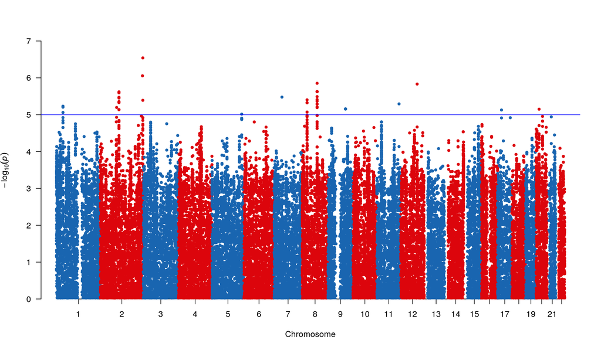

В анализе использовался мягкий порог на MAF. Рекомендуем использовать фильтр C_U $\geq$ 10 и C_A $\geq$ 10.

Первые 1000 строк результатов теста на ассоциацию:

| Imputed | DR2 | RS | SNP | Region | Gene | Minor allele | Major allele | MAF | Control allele count (C_U) | Case allele count (C_A) | Control allele freq (F_U) | Case allele freq (F_A) | Control Missing Rate (F_MISS_U) | Case Missing Rate (F_MISS_A) | P-value | SE | OR | OR 95% conf. int. |
| --- | --- | --- | --- | --- | --- | --- | --- | --- | --- | --- | --- | --- | --- | --- | --- | --- | --- | --- |
|  |  |  | rs35672139 |  |  | C | CT | 0.2973 | 204 | 85 | 0.3669 | 0.2043 | 0 | 0 | 2.88e-07 | 0.1757 | 0.4059 | (0.2876, 0.5728) |
|  |  |  | rs6710977 |  |  | T | G | 0.3076 | 216 | 83 | 0.3885 | 0.1995 | 0 | 0 | 8.795e-07 | 0.1607 | 0.4537 | (0.3311, 0.6217) |
|  |  |  | rs11780074 |  |  | T | G | 0.2407 | 160 | 74 | 0.2878 | 0.1779 | 0 | 0 | 1.404e-06 | 0.1802 | 0.4193 | (0.2946, 0.5969) |
|  |  |  | rs10532235 |  |  | CAT | C | 0.249 | 170 | 72 | 0.3058 | 0.1731 | 0 | 0 | 1.472e-06 | 0.1717 | 0.4375 | (0.3125, 0.6125) |
|  |  |  | rs10808854 |  |  | T | C | 0.2521 | 166 | 79 | 0.2986 | 0.1899 | 0 | 0 | 2.363e-06 | 0.1717 | 0.4448 | (0.3177, 0.6227) |
|  |  |  | rs12547399 |  |  | T | C | 0.2521 | 166 | 79 | 0.2986 | 0.1899 | 0 | 0 | 2.363e-06 | 0.1717 | 0.4448 | (0.3177, 0.6227) |
|  |  |  | rs201071342 |  |  | TAA | T | 0.2521 | 166 | 79 | 0.2986 | 0.1899 | 0 | 0 | 2.363e-06 | 0.1717 | 0.4448 | (0.3177, 0.6227) |
|  |  |  | rs4413772 |  |  | A | G | 0.2521 | 166 | 79 | 0.2986 | 0.1899 | 0 | 0 | 2.363e-06 | 0.1717 | 0.4448 | (0.3177, 0.6227) |
|  |  |  | rs4507760 |  |  | C | T | 0.2521 | 166 | 79 | 0.2986 | 0.1899 | 0 | 0 | 2.363e-06 | 0.1717 | 0.4448 | (0.3177, 0.6227) |
|  |  |  | rs4588851 |  |  | T | C | 0.2521 | 166 | 79 | 0.2986 | 0.1899 | 0 | 0 | 2.363e-06 | 0.1717 | 0.4448 | (0.3177, 0.6227) |

[output cut: 990 more lines]

Наши клиенты представляют собой гетерогенную популяцию. Убедимся в этом с помощью PCA (`plink`):

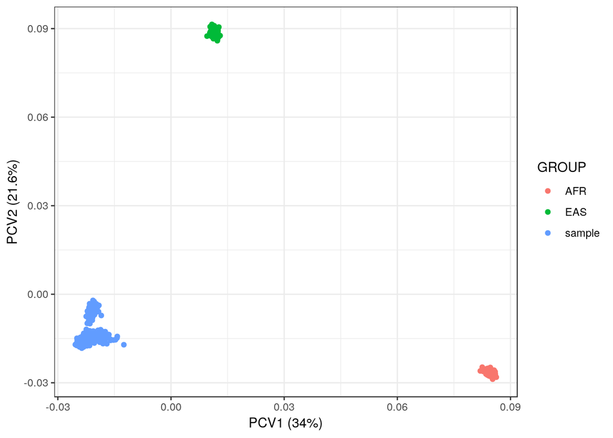

Посмотрим на структуру популяции после удаления выбросов (`smartpca`):

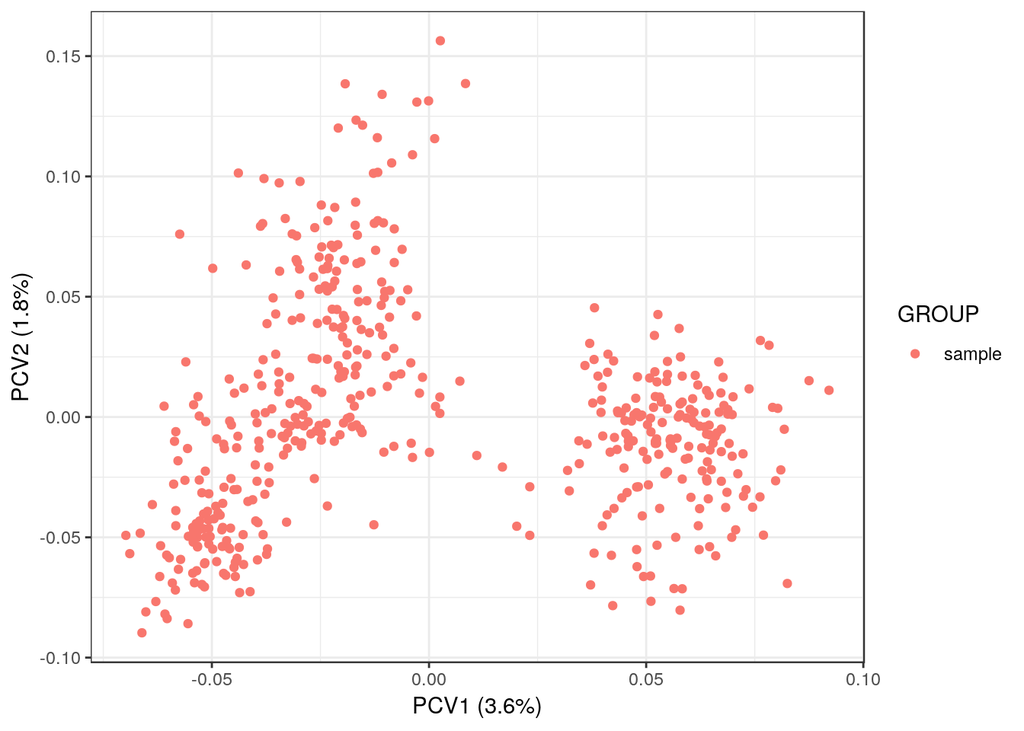

Были удалены следующие образцы:

| N | Prob | Pop |
| --- | --- | --- |
| 1 | NA11931 | Case |
| 2 | NA11932 | Case |
| 3 | NA11933 | Control |
| 4 | NA12383 | Control |
| 5 | NA12760 | Control |
| 6 | NA12830 | Case |
| 7 | HG00116 | Case |
| 8 | HG00120 | Control |
| 9 | NA12414 | Control |
| 10 | NA06985 | Control |
| 11 | NA12342 | Case |
| 12 | HG00240 | Control |

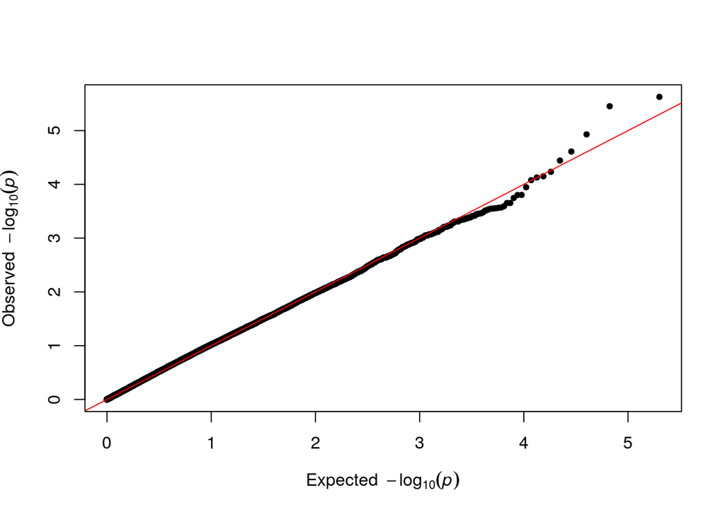

Гистограммы для каждого из предикторов:

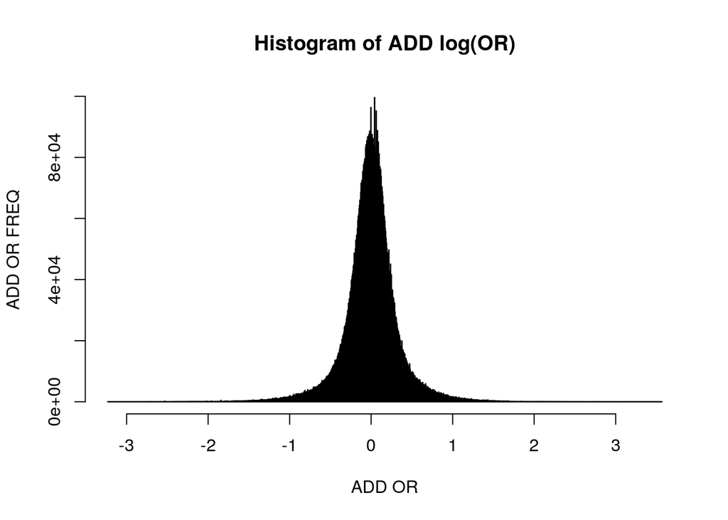

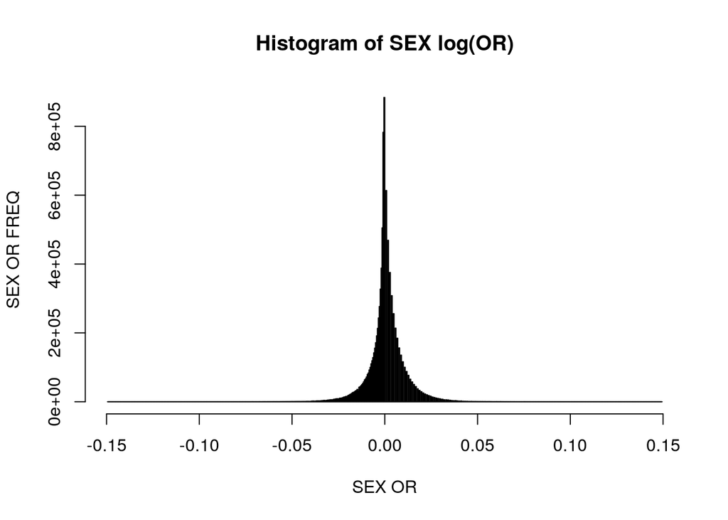

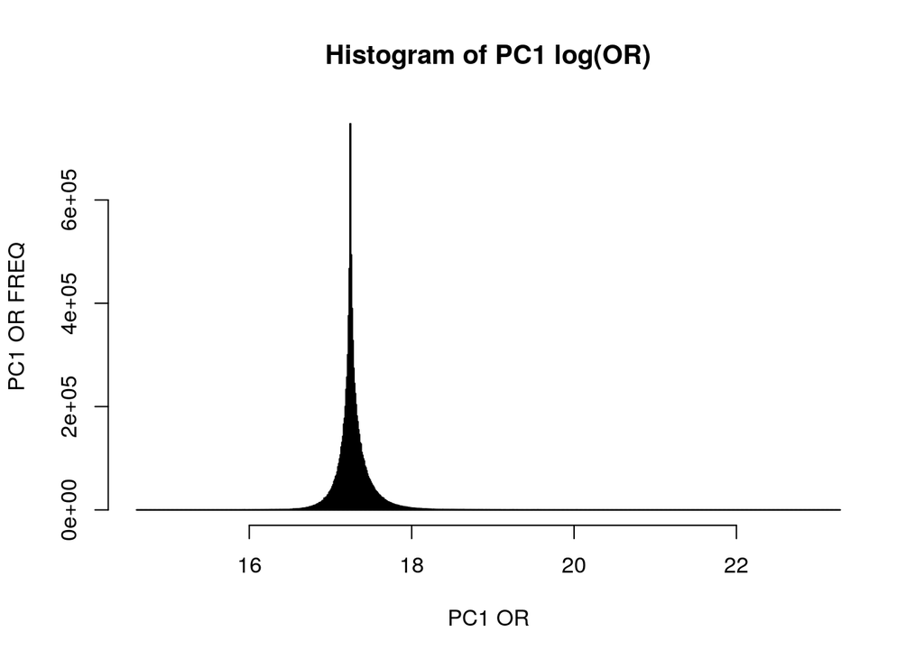

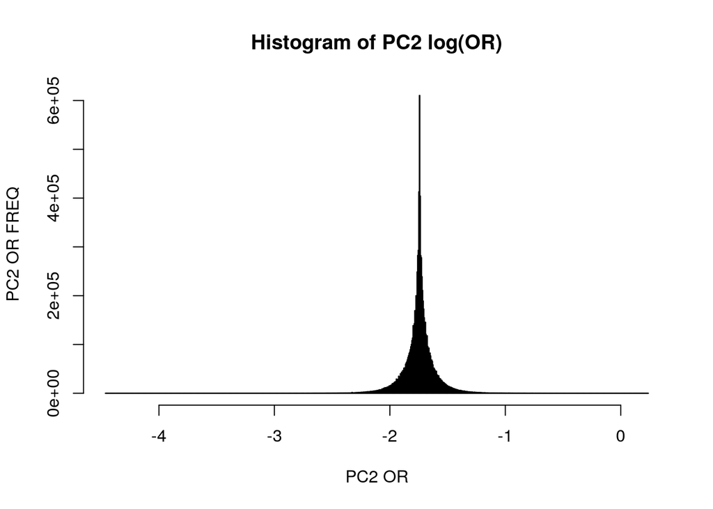

Пайплайн был разработан на основе следующих публикаций:

- Anderson, Carl A et al. Data quality control in genetic case-control association studies. Nature protocols vol. 5, 9 (2010): 1564-73.
- Pearson TA, Manolio TA. How to Interpret a Genome-wide Association Study. JAMA. 2008; 299(11): 1335-1344.

Дата генерации отчета: Thu May 23 19:46:43 2019